# Assignment 2

Huidi Lu, 20376663

## Simulate Data

1. Define variables

```r
beta_0 = 1
beta_l = 0.2
beta_k = 0.7
alpha = 0.7
sigma_eta = 0.2
sigma_nu = 0.5
sigma_w = 0.1
delta = 0.05
```

2. Define the `log_production` function

```r
log_production <- function(l,k,omega,eta,beta_0,beta_l,beta_k){
  return(beta_0+beta_l*l+beta_k*k+omega+eta)
}
```

3. Define the `log_labor_choice` function. I derive the formula by taking logrithm of equation 3.3 on both sides in the handout.

```r
log_labor_choice <- function(omega, k, w, beta_0, beta_l, beta_k, sigma_eta){
  return( (-log(w)+log(beta_l)+beta_0+omega+beta_k*k+0.5*sigma_eta^2)/(1-beta_l) )
}
```

4. Refine the previous function and name it `log_labor_choice_error`

```r
log_labor_choice_error <- function(omega, k, w, iota, beta_0, beta_l, beta_k, sigma_eta){
  return( log_labor_choice(omega+iota, k, w, beta_0, beta_l, beta_k, sigma_eta) )
}
```

5. Set $\gamma=0.1$. Define `investment_choice`.

```r
gamma = 0.1
```

```r
investment_choice <- function(delta,gamma,omega,K){
  return( (delta+gamma*omega)*K )
}
```

6. We see that $\omega_{jt}=0.7*\omega_{j,t-1}+\nu_{jt}$ where $\nu_{jt}\sim \mathbb{N}(0, 0.5^2)$. Clearly, the stationary distribution of $\omega_{jt}$ is normal with mean $m$ and standard deviation $s$ satisfying $m = 0.7*m+0$ and $s^2 = 0.7^2*s^2+0.5^2$. Therefore, $m=0, s^2=\frac{\sigma_\nu^2}{1-\alpha^2}=\frac{25}{51}$. Thus, we draw $\omega_{jt}$ from $\mathbb{N}(0, \frac{25}{51})$.

```r
set.seed(1)
df = tibble(j=rep(1:1000),t=rep(1,1000),k=1+rnorm(1000)/2,omega=rnorm(1000)*sqrt(sigma_nu^2 /(1-alpha^2)), wage=rep(0.5,1000))

df
```

```
## # A tibble: 1,000 x 5
##        j     t     k   omega  wage
##    <int> <dbl> <dbl>   <dbl> <dbl>
##  1     1     1 0.687  0.795    0.5
##  2     2     1 1.09   0.779    0.5
##  3     3     1 0.582 -0.610    0.5
##  4     4     1 1.80   0.148    0.5
##  5     5     1 1.16   0.0486   0.5
##  6     6     1 0.590 -1.16     0.5
##  7     7     1 1.24   0.568    0.5
##  8     8     1 1.37  -1.34     0.5
##  9     9     1 1.29  -0.873    0.5
## 10    10     1 0.847  0.699    0.5
## # ... with 990 more rows
```

```r
df$iota = 0.05*rnorm(1000)

df$l = log_labor_choice(omega=df$omega, k=df$k, w=df$wage, beta_0, beta_l, beta_k, sigma_eta)
df$l_error = log_labor_choice_error(omega=df$omega, k=df$k, w=df$wage, iota=df$iota, beta_0, beta_l, beta_k, sigma_eta)

df$I = investment_choice(delta=delta, gamma=gamma, omega=df$omega, K=exp(df$k))

df
```

```
## # A tibble: 1,000 x 9
##        j     t     k   omega  wage     iota      l l_error       I
##    <int> <dbl> <dbl>   <dbl> <dbl>    <dbl>  <dbl>   <dbl>   <dbl>
##  1     1     1 0.687  0.795    0.5 -0.0443   1.72   1.67    0.257
##  2     2     1 1.09   0.779    0.5 -0.0961   2.06   1.94    0.381
##  3     3     1 0.582 -0.610    0.5  0.0810  -0.123 -0.0218 -0.0196
##  4     4     1 1.80   0.148    0.5  0.0260   1.89   1.92    0.391
##  5     5     1 1.16   0.0486   0.5 -0.00279  1.21   1.21    0.176
##  6     6     1 0.590 -1.16     0.5  0.0348  -0.809 -0.766  -0.120
##  7     7     1 1.24   0.568    0.5  0.00268  1.93   1.93    0.370
##  8     8     1 1.37  -1.34     0.5 -0.0655  -0.346 -0.428  -0.330
##  9     9     1 1.29  -0.873    0.5 -0.106    0.165  0.0327 -0.135
## 10    10     1 0.847  0.699    0.5 -0.0104   1.74   1.73    0.280
## # ... with 990 more rows
```

8. Draw ex-post shock and compute the output.

```r
df$eta = sigma_eta*rnorm(1000)
df$y = log_production(l=df$l,k=df$k,omega=df$omega,eta=df$eta,beta_0,beta_l,beta_k)
df$y_error = log_production(l=df$l_error,k=df$k,omega=df$omega,eta=df$eta,beta_0,beta_l,beta_k)

df
```

```
## # A tibble: 1,000 x 12
##        j     t     k   omega  wage     iota      l l_error       I     eta
##    <int> <dbl> <dbl>   <dbl> <dbl>    <dbl>  <dbl>   <dbl>   <dbl>   <dbl>
##  1     1     1 0.687  0.795    0.5 -0.0443   1.72   1.67    0.257   0.148
##  2     2     1 1.09   0.779    0.5 -0.0961   2.06   1.94    0.381   0.0773
##  3     3     1 0.582 -0.610    0.5  0.0810  -0.123 -0.0218 -0.0196  0.259
##  4     4     1 1.80   0.148    0.5  0.0260   1.89   1.92    0.391  -0.161
##  5     5     1 1.16   0.0486   0.5 -0.00279  1.21   1.21    0.176  -0.321
##  6     6     1 0.590 -1.16     0.5  0.0348  -0.809 -0.766  -0.120   0.187
##  7     7     1 1.24   0.568    0.5  0.00268  1.93   1.93    0.370   0.361
##  8     8     1 1.37  -1.34     0.5 -0.0655  -0.346 -0.428  -0.330  -0.0113
##  9     9     1 1.29  -0.873    0.5 -0.106    0.165  0.0327 -0.135   0.377
## 10    10     1 0.847  0.699    0.5 -0.0104   1.74   1.73    0.280   0.316
## # ... with 990 more rows, and 2 more variables: y <dbl>, y_error <dbl>
```

9. Repeat the procedure for $t=1,\cdots10$.

```r
df$nu = rep(NA, 1000)

df_T = df

for (T in 2:10){
  df_next = df_T[df_T$t==T-1,]
  df_next$t = T
  df_next$nu = sigma_nu*rnorm(1000)
  df_next$omega = alpha*df_next$omega+df_next$nu
  df_next$k = log( (1-delta)*exp(df_next$k)+df_next$I )
  df_next$I = (delta+gamma*df_next$omega)*exp(df_next$k)
  df_next$l = log_labor_choice(omega=df_next$omega,k=df_next$k,w=df_next$wage,beta_0=beta_0,beta_l=beta_l,beta_k=beta_k, sigma_eta=sigma_eta)
  df_next$iota = 0.05*rnorm(1000)
  df_next$l_error = log_labor_choice_error(omega=df_next$omega,k=df_next$k,w=df_next$wage,iota=df_next$iota,beta_0=beta_0,beta_l=beta_l,beta_k=beta_k,sigma_eta=sigma_eta)
  df_next$eta = sigma_eta*rnorm(1000)
  df_next$y = log_production(l=df_next$l,k=df_next$k,omega=df_next$omega,eta=df_next$eta,beta_0,beta_l,beta_k)
  df_next$y_error = log_production(l=df_next$l_error,k=df_next$k,omega=df_next$omega,eta=df_next$eta,beta_0,beta_l,beta_k)
  df_T = rbind(df_T,df_next)
}


kable(descr(df_T,stats=c("n.valid", "mean", "sd", "min", "max"),transpose=TRUE),format="markdown")
```

|  | N.Valid | Mean | Std.Dev. | Min | Max |
| --- | --- | --- | --- | --- | --- |
| eta | 10000 | 0.0015825 | 0.2001539 | -0.7650371 | 0.7455922 |
| I | 10000 | 0.1793502 | 0.3006526 | -1.2722627 | 3.2975332 |
| iota | 10000 | -0.0000696 | 0.0502883 | -0.1841453 | 0.1715419 |
| j | 10000 | 500.5000000 | 288.6894251 | 1.0000000 | 1000.0000000 |
| k | 10000 | 0.9797900 | 0.5838949 | -1.2822534 | 3.2332312 |
| l | 10000 | 0.9799746 | 1.0965108 | -3.3281023 | 4.9679634 |
| l_error | 10000 | 0.9798876 | 1.0971595 | -3.3765433 | 4.9520674 |
| nu | 9000 | -0.0021155 | 0.4984324 | -2.1513907 | 1.8253882 |
| omega | 10000 | -0.0055826 | 0.7025102 | -2.5894171 | 2.6281307 |
| t | 10000 | 5.5000000 | 2.8724249 | 1.0000000 | 10.0000000 |
| wage | 10000 | 0.5000000 | 0.0000000 | 0.5000000 | 0.5000000 |
| y | 10000 | 1.8778479 | 1.1171035 | -2.4680251 | 6.1228291 |
| y_error | 10000 | 1.8778305 | 1.1169266 | -2.4777133 | 6.1196499 |

## Estimation

1. Regress $y_{jt}$ on $l_{jt}$ and $k_{jt}$. There is an upward bias because the efficiency of the firm $\omega_{jt}$ that is unobservable to the researcher is positively correlated with firm inputs. Directly regressing $y_{jt}$ on $l_{jt}$ and $k_{jt}$ will attribute all effects to the observables.

```r
ols = lm(formula=y_error~l_error+k, data=df_T)
summary(ols)
```

```
##
## Call:
## lm(formula = y_error ~ l_error + k, data = df_T)
##
## Residuals:
##      Min       1Q   Median       3Q      Max
## -0.73002 -0.14117 -0.00071  0.13743  0.87983
##
## Coefficients:
##             Estimate Std. Error t value Pr(>|t|)
## (Intercept) 0.892542   0.004058 219.966   <2e-16 ***
## l_error     0.997913   0.002396 416.454   <2e-16 ***
## k           0.007599   0.004503   1.688   0.0915 .
## ---
## Signif. codes:  0 '***' 0.001 '**' 0.01 '*' 0.05 '.' 0.1 ' ' 1
##
## Residual standard error: 0.2068 on 9997 degrees of freedom
## Multiple R-squared:  0.9657, Adjusted R-squared:  0.9657
## F-statistic: 1.408e+05 on 2 and 9997 DF,  p-value: < 2.2e-16
```

2. Regressing the first differences.

```r
df_T_within = tibble(dy_error = unlist( by(df_T$y_error, df_T$j, function(x){scale(x,scale = FALSE)}) ),
                     dl_error = unlist( by(df_T$l_error, df_T$j, function(x){scale(x,scale = FALSE)}) ),
                     dk = unlist( by(df_T$k, df_T$j, function(x){scale(x,scale = FALSE)}) )
                     )

dols = lm(formula=dy_error~-1+dl_error+dk, data=df_T_within)
summary(dols)
```

```
##
## Call:
## lm(formula = dy_error ~ -1 + dl_error + dk, data = df_T_within)
##
## Residuals:
##      Min       1Q   Median       3Q      Max
## -0.72450 -0.13285 -0.00244  0.12931  0.77657
##
## Coefficients:
##            Estimate Std. Error t value Pr(>|t|)
## dl_error  0.9910916  0.0029548 335.413   <2e-16 ***
## dk       -0.0009029  0.0127539  -0.071    0.944
## ---
## Signif. codes:  0 '***' 0.001 '**' 0.01 '*' 0.05 '.' 0.1 ' ' 1
##
## Residual standard error: 0.1961 on 9998 degrees of freedom
## Multiple R-squared:  0.9184, Adjusted R-squared:  0.9184
## F-statistic: 5.629e+04 on 2 and 9998 DF,  p-value: < 2.2e-16
```

3. The OP method. Use `npplreg` function of `np` package to estimate a partially linear model with a multivariate kernel. First use `npplregbw` to obtain the optimal band width and then use `npplreg` to estimate the model under the optimal bandwidth.

```r
bw_error <- npplregbw(y_error ~ l_error+k+I|k+I, df_T)
```

```r
res_op1_error <- npplreg(bws=bw_error)
summary(res_op1_error)
```

```
##
## Partially Linear Model
## Regression data: 10000 training points, in 5 variable(s)
## With 3 linear parametric regressor(s), 2 nonparametric regressor(s)
##
##                     y(z)
## Bandwidth(s): 0.07355059 0.01435558
##
##                     x(z)
## Bandwidth(s): 0.03908594 0.01191551
##               0.01397428 3.74953039
##               0.83529394 0.00398329
##
##                   l_error        k        I
## Coefficient(s): 0.2485295 2.355523 5.345145
##
## Kernel Regression Estimator: Local-Constant
## Bandwidth Type: Fixed
##
## Residual standard error: 0.1934585
## R-squared: 0.970064
##
## Continuous Kernel Type: Second-Order Gaussian
## No. Continuous Explanatory Vars.: 2
```

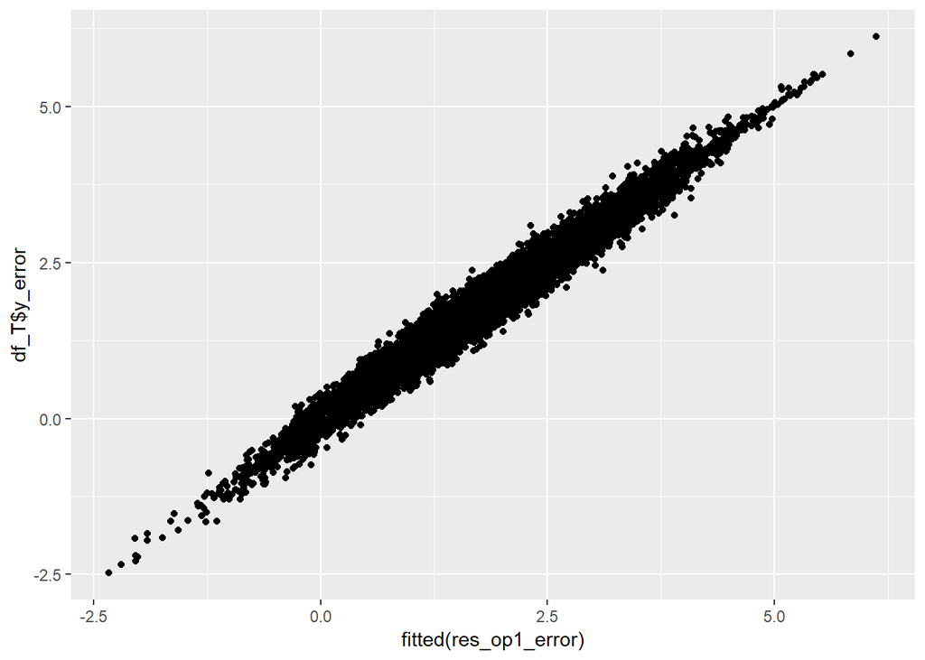

```r
qplot(fitted(res_op1_error), df_T$y_error)
```

4. Check that $\beta_l$ is not identified without optimization error. Estimate OP first-stage without optimization error.

```r
bw_no_error <- npplregbw(y ~ l+k+I|k+I, df_T)
```

```r
res_op1_no_error <- npplreg(bws=bw_no_error)
summary(res_op1_no_error)
```

```
##
## Partially Linear Model
## Regression data: 10000 training points, in 5 variable(s)
## With 3 linear parametric regressor(s), 2 nonparametric regressor(s)
##
##                     y(z)
## Bandwidth(s): 0.07347226 0.01437256
##
##                     x(z)
## Bandwidth(s): 0.02960021 0.009986945
##               0.01397428 3.749530394
##               0.83529394 0.003983290
##
##                        l        k         I
## Coefficient(s): 1.180628 2.034182 0.7805075
##
## Kernel Regression Estimator: Local-Constant
## Bandwidth Type: Fixed
##
## Residual standard error: 0.1932285
## R-squared: 0.970116
##
## Continuous Kernel Type: Second-Order Gaussian
## No. Continuous Explanatory Vars.: 2
```

5. OP 2nd stage. Save `df_T_1st`

```r
df_T_1st = df_T[,c('j','t')]
df_T_1st$y_error_tilde = df_T$y_error-df_T$l_error * coef(res_op1_error)[['l_error']]


phi_t = fitted(res_op1_error)-df_T$l_error * coef(res_op1_error)[['l_error']]

ORDER = order(df_T_1st$j)
df_T_1st = df_T_1st[ORDER,]

df_T_1st$phi_t_1 = unlist( by(phi_t[ORDER], df_T_1st$j, function(x){c(NA,x[1:9])} ) )
df_T_1st
```

```
## # A tibble: 10,000 x 4
##        j     t y_error_tilde phi_t_1
##    <int> <dbl>         <dbl>   <dbl>
##  1     1     1         2.34   NA
##  2     1     2         1.37    2.21
##  3     1     3         0.621   1.49
##  4     1     4         0.447   0.882
##  5     1     5         0.878   0.611
##  6     1     6         1.62    0.926
##  7     1     7         0.558   1.40
##  8     1     8         0.684   0.439
##  9     1     9         0.939   0.520
## 10     1    10         1.49    0.836
## # ... with 9,990 more rows
```

6. Define the moment function. Show the value evaluated at the true parameters

```r
moment_OP_2nd <- function(alpha, beta_0, beta_k, df_T, df_T_1st){
  df_T=df_T[order(df_T$j),]
  df_T$k_1 = unlist( by(df_T$k, df_T$j, function(x){c(NA,x[1:9])} ) )
  df_T$I_1 = unlist( by(df_T$I, df_T$j, function(x){c(NA,x[1:9])} ) )

  op2resid = df_T_1st$y_error_tilde+(alpha-1)*(beta_0+beta_k*df_T$k)-alpha*df_T_1st$phi_t_1

  moments = tibble(m1=op2resid*df_T$k, m2=op2resid*df_T$k_1, m3=op2resid*df_T$I_1)

  return( colMeans(moments, na.rm=TRUE) )
}
```

```r
moment_OP_2nd(alpha=alpha, beta_0=beta_0, beta_k=beta_k, df_T=df_T, df_T_1st=df_T_1st)
```

```
##           m1           m2           m3
## -0.013764608 -0.016742471  0.003871087
```

7. Define the GMM objective function. Show the value evaluated at the true parameters

```r
objective_OP_2nd <- function(params, df_T, df_T_1st){
  mmt = moment_OP_2nd(params[1], params[2], params[3], df_T, df_T_1st)
  return( mmt %*% mmt )
}
```

```r
objective_OP_2nd(params=c(alpha,beta_0,beta_k), df_T=df_T, df_T_1st=df_T_1st)
```

```
##              [,1]
## [1,] 0.0004847601
```

8. Draw the graph when one of $\alpha$, $\beta_0$ and $\beta_k$ is changed from 0 to 1 by 0.1 while others are set at the true value. We see that the objective is indeed minimized at the true value.

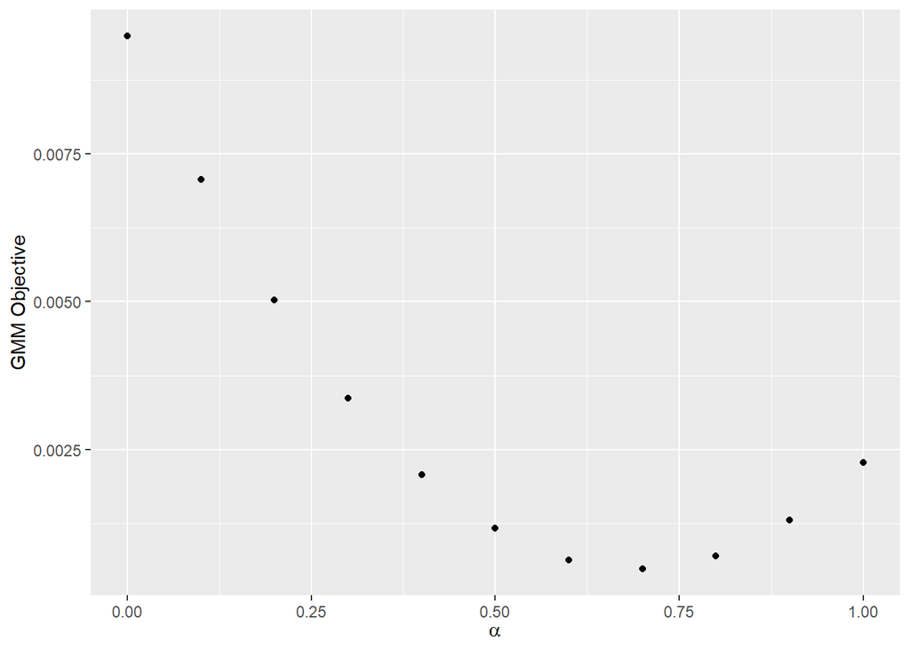

```r
p1=apply(as.array(0:10/10),1,function(x){objective_OP_2nd(params=c(x,beta_0,beta_k), df_T=df_T, df_T_1st=df_T_1st)})
qplot(0:10/10, p1 ,xlab=expression(alpha), ylab='GMM Objective')
```

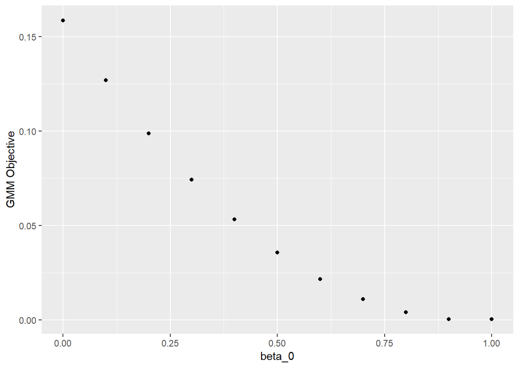

```r
p2=apply(as.array(0:10/10),1,function(x){objective_OP_2nd(params=c(alpha,x,beta_k), df_T=df_T, df_T_1st=df_T_1st)})
qplot(0:10/10, p2 ,xlab=expression(beta_0), ylab='GMM Objective')
```

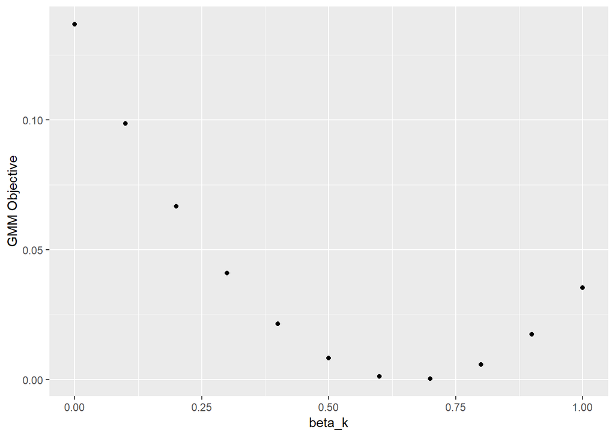

```r
p3=apply(as.array(0:10/10),1,function(x){objective_OP_2nd(params=c(alpha,beta_0,x), df_T=df_T, df_T_1st=df_T_1st)})
qplot(0:10/10, p3 ,xlab=expression(beta_k), ylab='GMM Objective')
```

9. Find the parameters using `optim` and `L-BFGS-B` method.

```r
optim(runif(3), objective_OP_2nd, df_T=df_T, df_T_1st=df_T_1st, method='L-BFGS-B')
```

```
## $par
## [1] 0.7644545 1.1432840 0.5372573
##
## $value
## [1] 2.831057e-07
##
## $counts
## function gradient
##       25       25
##
## $convergence
## [1] 0
##
## $message
## [1] "CONVERGENCE: REL_REDUCTION_OF_F <= FACTR*EPSMCH"
```